# Part II - Income and Health. What does the data say?

## by Olubunmi Adejimi

## Introduction

> Apart from geographical classifications, countries are most commonly classified based on their economic status.

> The Gross national Income (GNI) per capita serves as as an index that truly represents the income level of citizens in a country.

> Many parameters can be used to represent the health condition of a nation, including:
> - Life expectancy
> - Maternal Mortality
> - Infant Mortality

> The relationship between income and these health parameters is important to understand the effect of economy on health.

## Income level

> The World Bank classifies countries based on their GNI per capita to 4 income levels: High income, Upper-middle income, Lower-middle income and Low income.

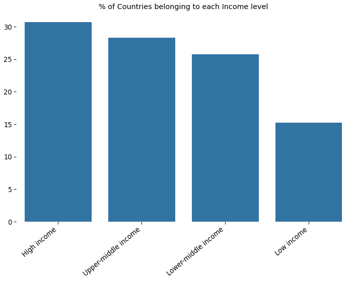

## Question 1.

> Has the number of countries in each income level changed between 2010 and 2020?

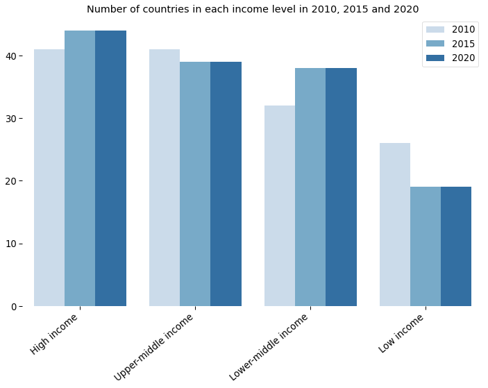

> Over the 10 years period the income level of various countries has improved. The number of **High income** and **Lower-middle income** countries increased and there are less **Low income** and **Upper-middle income** countries in 2020 compared to 2010.

## Question 2.

> What is relationship between GNI per capita and health parameters, as well, as population growth and fertility rate?

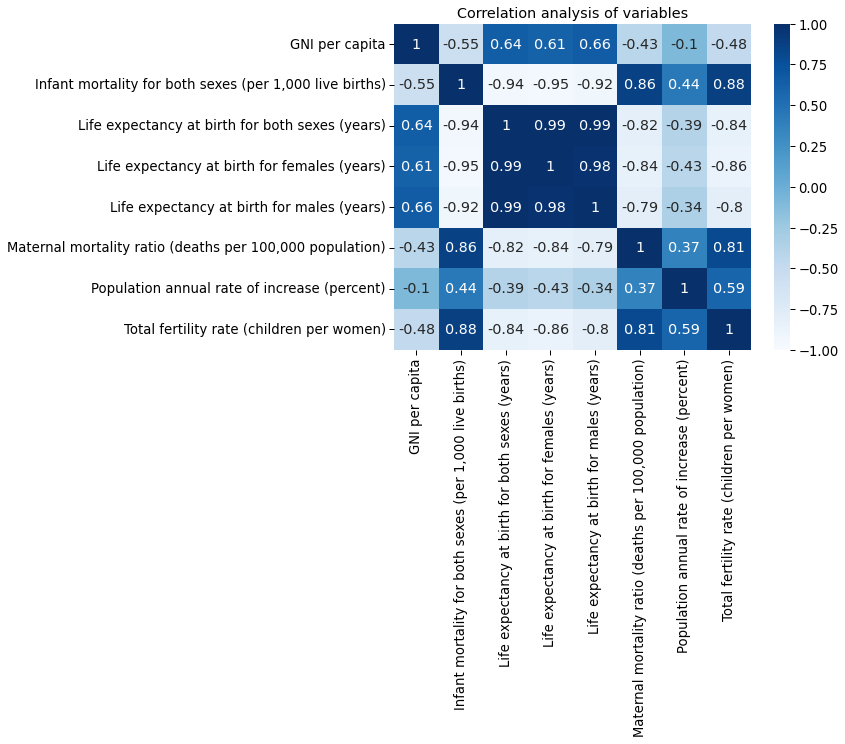

> Maternal mortality is strongly correlated (r=0.86) to Infant mortality, indicating that infants that lose their mothers have a lower chance at survival.

## Question 3.

> How does geographic group and income level impact these health parameters?

> Effect of **Income** on **Infant Mortality** by region and income level

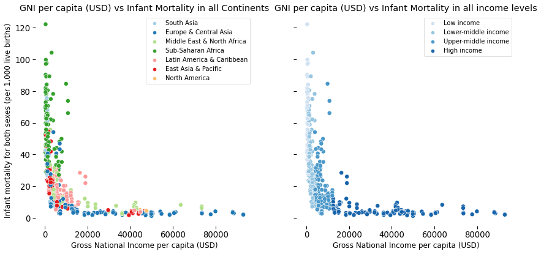

> GNI per capita has a negative non-linear relationship to Infant mortality.

> Sub-saharan Africa and parts of South Asia have the highest infant mortality rate.

> Low-income and lower-middle income countries are more likely to have high infant mortality.

> Effect of **Income** on **Maternal Mortality** by region and income level.

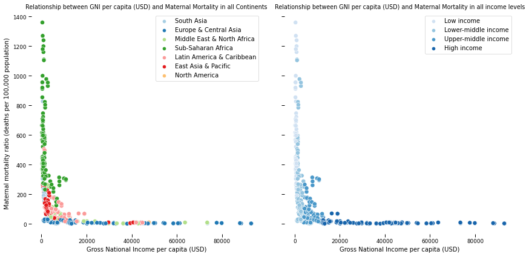

> GNI per capita has a negative non-linear relationship to Maternal mortality.

> Sub-saharan Africa countries have the highest maternal mortality rate.

> Low-income and Lower-middle income countries are more likely to have high maternal mortality.

> Effect of **Income** on **Life expectancy** by region and income level

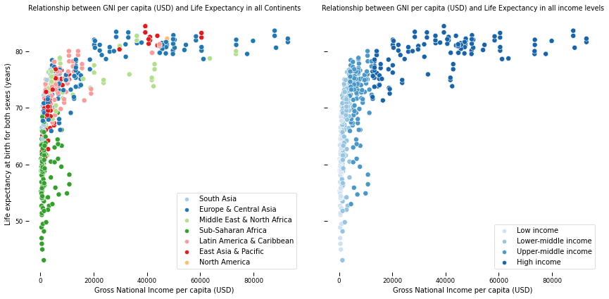

> GNI per capita has a positive non-linear relationship to life expectancy.

> Sub-saharan African countries have the lowest life expectancy with some countries having life expectancy lower than 50 years old.

> Low-income and Lower-middle income countries are more likely to have lower life expectancies. Some Upper-middle income countries also have low life expectancies.

> The effect of the **GNI per capita** on these health *indicators* in different regions and income levels, reveals a pattern of low income economies having worse health, predominated by Sub-saharan African countries.

## Question 4.

> Has the health (Life expectancy) of the countries improved over time?

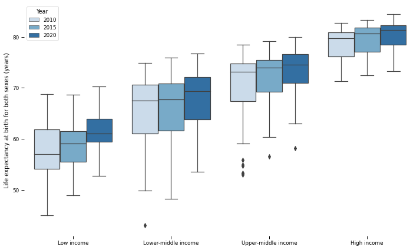

> Focusing on Life expectancy as an indicator of health and well-being, the health of citizens have improved regardless of their income level.

> Although **low income** countries have seen the highest change in median life expectancy between 2010 and 2020, they still have the lowest life expectancy ranging from 45 to 70 years of life, while **high income** countries range from >70 to 80+ years.

## Conclusions

> Maternal health and infant health suffers in the least developed countries. This highlights the need for improved healthcare and economic development to help improve the health of infant and mothers. Being a wealthy individual or country increases life expectancy. This may be due to better access to healthcare and better quality of life due to higher income levels.